# Capstone Project

*The project aims to analyse crime patterns and outcomes between rural and urban areas in Kent. It will apply spatial enrichment and machine learning techniques to evaluate if observed patterns from 2024-2025 data align with previously identified community priorities.*

```python
import warnings
warnings.filterwarnings("ignore")
```

## 1 - Gathering Data

```python
# Loop files and concatenate
from pathlib import Path
import pandas as pd

# Path to the folder KENT_CRIME
base_path = Path("KENT_CRIME")

# Lists for monthly dfs
street_dfs = []
outcome_dfs = []

# Loop through all YYYY-MM folders
for month_folder in sorted(base_path.iterdir()):
    if month_folder.is_dir():

        # Find matching files
        street_files = list(month_folder.glob("*-kent-street.csv"))
        outcome_files = list(month_folder.glob("*-kent-outcomes.csv"))

        # Load street data
        for file in street_files:
            df = pd.read_csv(file)
            street_dfs.append(df)

        # Load outcomes data
        for file in outcome_files:
            df = pd.read_csv(file)
            outcome_dfs.append(df)

# Combine into final dataframes
crime_data = pd.concat(street_dfs, ignore_index=True)
crime_outcomes = pd.concat(outcome_dfs, ignore_index=True)

# Optional: inspect results
print("Crime data shape:", crime_data.shape)
print("Crime outcomes shape:", crime_outcomes.shape)

# # Preview
# display(crime_data.head())
# display(crime_outcomes.head())
```

```
Crime data shape: (363507, 12)
Crime outcomes shape: (322613, 10)
```

```python
# Crime Data Handling
crime_data = crime_data.drop([
    'Reported by','Falls within','Longitude','Latitude','Location','LSOA name','Context'
    ], axis=1)
crime_data.info()
```

```
<class 'pandas.core.frame.DataFrame'>
RangeIndex: 363507 entries, 0 to 363506
Data columns (total 5 columns):
 #   Column                 Non-Null Count   Dtype
---  ------                 --------------   -----
 0   Crime ID               305621 non-null  object
 1   Month                  363507 non-null  object
 2   LSOA code              359238 non-null  object
 3   Crime type             363507 non-null  object
 4   Last outcome category  305621 non-null  object
dtypes: object(5)
memory usage: 13.9+ MB
```

```python
# Crime Outcomes Data Handling
crime_outcomes = crime_outcomes.drop([
    'Reported by','Falls within','Longitude','Latitude','Location','LSOA name'
    ], axis=1)

crime_outcomes = crime_outcomes.rename(columns={
    'Month':'Outcome_Month',
    'LSOA code':'Outcome_LSOA',
    })

crime_outcomes.info()
```

```
<class 'pandas.core.frame.DataFrame'>
RangeIndex: 322613 entries, 0 to 322612
Data columns (total 4 columns):
 #   Column         Non-Null Count   Dtype
---  ------         --------------   -----
 0   Crime ID       322613 non-null  object
 1   Outcome_Month  322613 non-null  object
 2   Outcome_LSOA   318267 non-null  object
 3   Outcome type   322613 non-null  object
dtypes: object(4)
memory usage: 9.8+ MB
```

```python
# Crime & Outcomes & Rural/Urban join
crime_data_all = pd.merge(
    crime_data,
    crime_outcomes,
    on = 'Crime ID',
    how = 'inner'
)

crime_data_all = crime_data_all.drop(columns=[
    'Outcome_Month','Outcome_LSOA'
]).dropna().drop_duplicates()

rural_urban = pd.read_csv('lsoa_rural_urban.csv')

rural_urban = rural_urban.drop(
    ['LSOA21NM','LSOA21NMW','RUC21CD','RUC21NM','ObjectId'], axis=1
    ).rename(columns=
             {'LSOA21CD':'LSOA code'}
    )


rural_urban_crime = pd.merge(
    crime_data_all,
    rural_urban,
    on = 'LSOA code',
    how = 'inner'
)

rural_urban_crime.info()
```

```
<class 'pandas.core.frame.DataFrame'>
RangeIndex: 285895 entries, 0 to 285894
Data columns (total 7 columns):
 #   Column                 Non-Null Count   Dtype
---  ------                 --------------   -----
 0   Crime ID               285895 non-null  object
 1   Month                  285895 non-null  object
 2   LSOA code              285895 non-null  object
 3   Crime type             285895 non-null  object
 4   Last outcome category  285895 non-null  object
 5   Outcome type           285895 non-null  object
 6   Urban_rural_flag       285895 non-null  object
dtypes: object(7)
memory usage: 15.3+ MB
```

## 2 - EDA: Data Exploration

How do the frequency, types, and outcomes of crime differ between rural and urban areas in Kent?

### 2.1 - Counts & Proportions

```python
# Crime Frequency
freq = (
    rural_urban_crime
    .groupby('Urban_rural_flag')
    .size()
    .reset_index(name='Number of Crimes')
)

freq['pct'] = round((
    freq['Number of Crimes'] / freq['Number of Crimes'].sum()
) * 100,2)

freq
```

|  | Urban_rural_flag | Number of Crimes | pct |
| --- | --- | --- | --- |
| 0 | Rural | 42066 | 14.71 |
| 1 | Urban | 243829 | 85.29 |

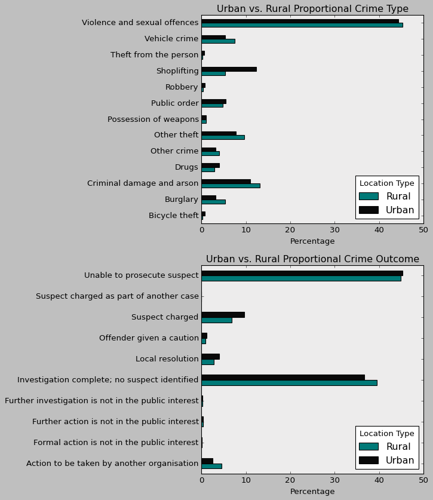

```python
# [Proportions] Crime Types / Outcomes
import matplotlib.pyplot as plt

type_proportions = pd.crosstab(
    rural_urban_crime["Crime type"],
    rural_urban_crime["Urban_rural_flag"],
    normalize = 'columns'
) * 100

outcome_proportions = pd.crosstab(
    rural_urban_crime["Outcome type"],
    rural_urban_crime["Urban_rural_flag"],
    normalize = 'columns'
) * 100

colors = {
    "Urban": "#090909",
    "Rural": "#007a78"
}

type_proportions = type_proportions[sorted(type_proportions.columns)]
outcome_proportions = outcome_proportions[sorted(outcome_proportions.columns)]

fig, axes = plt.subplots(2,1, figsize=(6,12))
plt.style.use('classic')

## Crime type plot
type_proportions.plot(
    kind = "barh",
    ax = axes[0],
    color=[colors.get(col, "grey") for col in type_proportions.columns],
)

axes[0].set_title("Urban vs. Rural Proportional Crime Type")
axes[0].set_xlabel("Percentage")
axes[0].set_ylabel("")
axes[0].legend(title = "Location Type", loc='lower right')
axes[0].set_facecolor("#EDECEC")


## Crime outcomes plot
outcome_proportions.plot(
    kind = "barh",
    ax = axes[1],
    color=[colors.get(col, "lightgrey") for col in outcome_proportions.columns]

)

axes[1].set_title("Urban vs. Rural Proportional Crime Outcome")
axes[1].set_xlabel("Percentage")
axes[1].set_ylabel("")
axes[1].legend(title = "Location Type", loc='lower right')
axes[1].set_facecolor("#EDECEC")
```

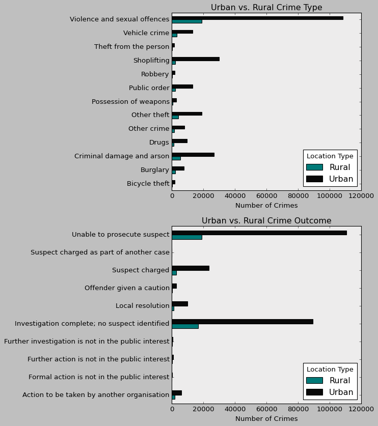

```python
# Crime Types / Outcomes

type_counts = pd.crosstab(
    rural_urban_crime["Crime type"],
    rural_urban_crime["Urban_rural_flag"]
)

outcome_counts = pd.crosstab(
    rural_urban_crime["Outcome type"],
    rural_urban_crime["Urban_rural_flag"]
)

colors = {
    "Urban": "#090909",
    "Rural": "#007a78"
}

type_counts = type_counts[sorted(type_counts.columns)]
outcome_counts = outcome_counts[sorted(outcome_counts.columns)]

fig, axes = plt.subplots(2,1, figsize=(6,12))
plt.style.use('classic')

## Crime type plot
type_counts.plot(
    kind = "barh",
    ax = axes[0],
    color=[colors.get(col, "grey") for col in type_counts.columns],
)

axes[0].set_title("Urban vs. Rural Crime Type")
axes[0].set_xlabel("Number of Crimes")
axes[0].set_ylabel("")
axes[0].legend(title = "Location Type", loc='lower right')
axes[0].set_facecolor("#EDECEC")


## Crime outcomes plot
outcome_counts.plot(
    kind = "barh",
    ax = axes[1],
    color=[colors.get(col, "lightgrey") for col in outcome_counts.columns]

)

axes[1].set_title("Urban vs. Rural Crime Outcome")
axes[1].set_xlabel("Number of Crimes")
axes[1].set_ylabel("")
axes[1].legend(title = "Location Type", loc='lower right')
axes[1].set_facecolor("#EDECEC")
```

### 2.2 - EDA Findings

Recorded crime is much higher in urban areas, accounting for $\approx 85\%$ of crimes, compared to $\approx 15\%$ in rural areas. This indicates a substancial imbalance in recorded crime volume, although the data is not adjusted for population size, Additionally, this could be indicative of potential under-reporting of rural crime as reported in literature.

Recorded crime types are broadly consistent when looking proportionally across Kent, although there are some clear distinctions between urban and rural areas. Shoplifting offences occur twice as much in urban areas, whilst there are marginally higher proportions of criminal damage and arson, vehicle crime, violence and sexual offences, and other crime in rural areas. Overall, violence and sexual offences dominate offences recorded, accounting for more than $40\%$ of crimes in both urban and rural areas.

Raw counts show interesting insights. The 3 most recorded crime types in urab areas are violence and sexual offences, criminal damage and arson, and shoplifting. This differs to violence and sexual offences, criminal damage and arson and other theft for rural areas. The 3 most recorded crime outcomes in urban areas are "Unable to prosecute suspect", "Investigation complete; no suspect identified", and "suspect charged". This does not differ to rural areas.

### 2.3 - Statistical Significance: Chi-Squared Testing

1. Crime Type
   - $H_0: \text{"Crime type is independent of urban/rural classification"}$
   - $H_1: \text{"Crime type is associated with urban/rural classification"}$
2. Crime Outcome
   - $H_0: \text{"Crime outcome is independent of urban/rural classification"}$
   - $H_1: \text{"Crime outcome is associated with urban/rural classification"}$

```python
chi_crime_type = pd.crosstab(
    rural_urban_crime["Urban_rural_flag"],
    rural_urban_crime["Crime type"]
)

chi_crime_outcome = pd.crosstab(
    rural_urban_crime["Urban_rural_flag"],
    rural_urban_crime["Outcome type"]
)

from scipy.stats import chi2_contingency
from scipy.stats.contingency import association


type_chi2, type_p, type_dof, type_expected = chi2_contingency(chi_crime_type)
out_chi2, out_p, out_dof, out_expected = chi2_contingency(chi_crime_outcome)

print(
    f"CRIME TYPE INDEPENDENCE TEST\nChi2 = {round(type_chi2,2)}\np = {type_p}\nDOF = {type_dof}"
)
print(
    f"Cramer's V = {round(association(chi_crime_type,method='cramer'),4)}\n"
)

print(
    f"CRIME OUTCOME INDEPENDENCE TEST\nChi2 = {round(out_chi2,2)}\np = {out_p}\nDOF = {out_dof}"
)
print(
    f"Cramer's V = {round(association(chi_crime_outcome,method='cramer'),4)}"
)
```

```
CRIME TYPE INDEPENDENCE TEST
Chi2 = 3159.95
p = 0.0
DOF = 12
Cramer's V = 0.1051

CRIME OUTCOME INDEPENDENCE TEST
Chi2 = 1089.33
p = 9.325468171661566e-229
DOF = 9
Cramer's V = 0.0617
```

## 3 - Multinomial Logistic Regression

Can crime type be predicted using spatial and temporal features?

### 3.1 - Assess Model Feasibility

```python
# Assessing Class Imbalance in Crime Type
# Robbery / Bicycle theft / Theft from the person occur <1%
# Remove these types
removals_crime_type = ['Robbery','Bicycle theft','Theft from the person']
multinomial_data = rural_urban_crime[~rural_urban_crime['Crime type'].isin(removals_crime_type)].copy()
```

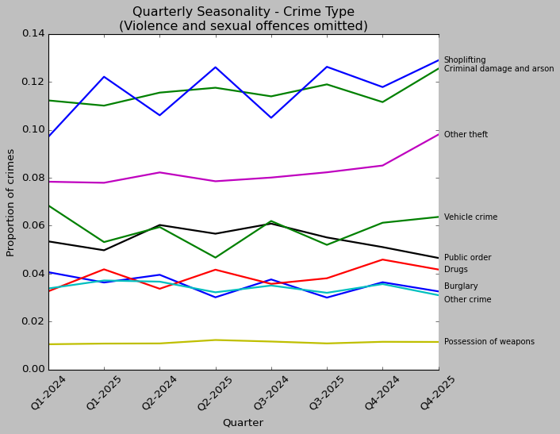

```python
# Assessing temporal seasonality

multinomial_data["DMonth"] = pd.to_datetime(multinomial_data["Month"])
multinomial_data["Quarter"] = (
    "Q" + multinomial_data["DMonth"].dt.quarter.astype(str) + "-" +
    multinomial_data["DMonth"].dt.year.astype(str)
)
multinomial_quarterly = pd.crosstab(
    multinomial_data["Quarter"], multinomial_data["Crime type"], normalize="index"
)

import numpy as np

plt.figure(figsize=(9,7))
plt.style.use('classic')

x = np.arange(len(multinomial_quarterly.index))

for crime_type in multinomial_quarterly.columns:

    if crime_type == "Violence and sexual offences":
        continue

    y = multinomial_quarterly[crime_type].values
    plt.plot(x, y, linewidth=2)

    # default no offset
    y_offset = 0

    # manual separation for overlapping labels
    if crime_type == "Burglary":
        y_offset = 0.002
    elif crime_type == "Other crime":
        y_offset = -0.002

    plt.text(
        x[-1] + 0.1,
        y[-1] + y_offset,
        crime_type,
        fontsize=9,
        va='center'
    )

plt.xticks(x, multinomial_quarterly.index, rotation=45)

plt.xlabel("Quarter")
plt.ylabel("Proportion of crimes")
plt.title("Quarterly Seasonality - Crime Type\n(Violence and sexual offences omitted)")

ax = plt.gca()
ax.spines["right"].set_visible(False)
plt.tight_layout()
plt.show()

# Temporal features hold some statistical value.
# Temporal features are feasible for the model.
# Seasonality is not consistently strong enough to be a sole predictor
```

### 3.2 - Building the Model

```python
# Removing irrelevant columns
multinomial_data2 = multinomial_data.drop([
    "Crime ID","Month","LSOA code","Last outcome category",
    "Outcome type","DMonth"
],axis=1)
```

```python
# Model pipeline
X = multinomial_data2[["Urban_rural_flag","Quarter"]]
y = multinomial_data2["Crime type"]

from sklearn.model_selection import train_test_split

X_train, X_test, y_train, y_test = train_test_split(
    X,
    y,
    test_size=0.2,
    random_state=13,
    stratify=y  # Stratify for class imbalance
)

from sklearn.preprocessing import OneHotEncoder
from sklearn.compose import ColumnTransformer
from sklearn.pipeline import Pipeline
from sklearn.linear_model import LogisticRegression

preprocess = ColumnTransformer(
    transformers=[
        ("cat", OneHotEncoder(handle_unknown="ignore"), ["Urban_rural_flag", "Quarter"])
    ]
)

logistic_model = LogisticRegression(
    # multi_class="multinomial",  # Avoiding warning
    solver="lbfgs",
    class_weight="balanced",
    max_iter=500
)

pipeline = Pipeline(steps=[
    ("preprocess", preprocess),
    ("model", logistic_model)
])

pipeline.fit(X_train,y_train)
y_pred = pipeline.predict(X_test)
```

#### 3.2.1 - Model Evaluation

```python
# Evaluation - Classification Report
from sklearn.metrics import classification_report, f1_score

print(classification_report(y_test, y_pred))
```

```
                              precision    recall  f1-score   support

                    Burglary       0.06      0.21      0.09      1994
   Criminal damage and arson       0.00      0.00      0.00      6459
                       Drugs       0.05      0.13      0.07      2168
                 Other crime       0.00      0.00      0.00      1924
                 Other theft       0.09      0.02      0.03      4609
       Possession of weapons       0.00      0.00      0.00       631
                Public order       0.06      0.25      0.10      3056
                 Shoplifting       0.14      0.47      0.21      6468
               Vehicle crime       0.07      0.13      0.09      3263
Violence and sexual offences       0.00      0.00      0.00     25445

                    accuracy                           0.09     56017
                   macro avg       0.05      0.12      0.06     56017
                weighted avg       0.03      0.09      0.04     56017
```

### 3.3 - Model Revisions

```python
# Revisit the initial data
multinomial_data3 = multinomial_data.copy()

# Removing columns
multinomial_data3 = multinomial_data.drop([
    "Crime ID","Month","Last outcome category",
    "Outcome type","DMonth"
],axis=1)

# Introduce temporal-spatial interation
multinomial_data3["Spatial_quarter"] = (
    multinomial_data3["Urban_rural_flag"].astype(str)
    + "_" +
    multinomial_data3["Quarter"]
)

X2 = multinomial_data3[["Urban_rural_flag","Quarter","Spatial_quarter","LSOA code"]]
y2 = multinomial_data3["Crime type"]

X_train, X_test, y_train, y_test = train_test_split(
    X2,
    y2,
    test_size=0.2,
    random_state=13,
    stratify=y
)

# Introduce frequency encoding on LSOA
lsoa_freq = X_train["LSOA code"].value_counts(normalize=True)
X_train["LSOA_freq"] = X_train["LSOA code"].map(lsoa_freq)
X_test["LSOA_freq"] = X_test["LSOA code"].map(lsoa_freq)
X_test["LSOA_freq"] = X_test["LSOA_freq"].fillna(0)

# Rebuild the model
preprocess = ColumnTransformer(
    transformers=[
        ("cat", OneHotEncoder(handle_unknown="ignore"), [
            "Urban_rural_flag","Quarter","Spatial_quarter"])
    ]
)

logistic_model = LogisticRegression(
    # multi_class="multinomial",  # Avoiding warning
    solver="lbfgs",
    class_weight="balanced",
    max_iter=500
)

pipeline = Pipeline(steps=[
    ("preprocess", preprocess),
    ("model", logistic_model)
])

pipeline.fit(X_train,y_train)
y_pred = pipeline.predict(X_test)
```

#### 3.3.1 - Model Evaluation

```python
# Evaluation - Classification Report Pt.2
print(classification_report(y_test, y_pred))
```

```
                              precision    recall  f1-score   support

                    Burglary       0.06      0.13      0.08      1994
   Criminal damage and arson       0.00      0.00      0.00      6459
                       Drugs       0.05      0.13      0.07      2168
                 Other crime       0.00      0.00      0.00      1924
                 Other theft       0.10      0.04      0.06      4609
       Possession of weapons       0.00      0.00      0.00       631
                Public order       0.06      0.25      0.10      3056
                 Shoplifting       0.14      0.47      0.21      6468
               Vehicle crime       0.07      0.18      0.10      3263
Violence and sexual offences       0.00      0.00      0.00     25445

                    accuracy                           0.09     56017
                   macro avg       0.05      0.12      0.06     56017
                weighted avg       0.04      0.09      0.05     56017
```

### 3.4 - Conclusion

Based on the available temportal and spatial features in the dataset, crime type cannot be reliably predicted.

## 4 - Random Forest / Gradient Boosting

Do predicted crime outcomes differ systematically between rural and urban areas, and do these patterns align with community policing priorities?

### 4.1 - Assess Model Feasibility

Exploratory analysis in Section 2.1 identified substantial class imbalance within recorded crime outcomes. The original multiclass outcome variable contains several infrequently observed categories, which may reduce classification performance and limit the effectiveness of ensemble methods. To address this issue, crime outcomes are reclassified into a binary outcome representing either Resolved or Unresolved cases.

This reclassification introduces important ethical considerations regarding interpretation. A resolved outcome should not be interpreted as evidence of successful policing, victim satisfaction, or positive criminal justice outcomes. Instead, the binary classification reflects whether a recorded investigation reached a formal conclusion according to the official outcome definitions. In the absence of additional contextual information, the published outcome descriptions are treated as the most appropriate ground truth for classification. Thus the analysis evaluates case resolution rather than perceptions of policing effectiveness or sentiment.

```python
# Build ensemble data
ensemble_data = rural_urban_crime.copy()

# Copy in previously used features
ensemble_data["DMonth"] = pd.to_datetime(ensemble_data["Month"])

ensemble_data["Quarter"] = (
    "Q" + ensemble_data["DMonth"].dt.quarter.astype(str) + "-" +
    ensemble_data["DMonth"].dt.year.astype(str)
)

ensemble_data["Spatial_quarter"] = (
    ensemble_data["Urban_rural_flag"].astype(str)
    + "_" +
    ensemble_data["Quarter"]
)

# Reclassify outcomes
ensemble_data = ensemble_data.replace({
    "Outcome type" : {
        'Suspect charged' : 'Resolved',
        'Action to be taken by another organisation' : 'Resolved',
        'Investigation complete; no suspect identified' : 'Resolved',
        'Suspect charged as part of another case' : 'Resolved',
        'Local resolution' : 'Resolved',
        'Offender given a caution' : 'Resolved',

        'Further action is not in the public interest' : 'Unresolved',
        'Further investigation is not in the public interest' : 'Unresolved',
        'Formal action is not in the public interest' : 'Unresolved',
        'Unable to prosecute suspect' : 'Unresolved'
    }
})

# test-train-split
# LSOA freq after test-train-split
X = ensemble_data[["Urban_rural_flag","Quarter","Spatial_quarter","Crime type","LSOA code"]]
y = ensemble_data["Outcome type"]

X_train, X_test, y_train, y_test = train_test_split(
    X,
    y,
    test_size=0.2,
    random_state=13,
    stratify=y
)

# Introduce frequency encoding on LSOA
lsoa_freq = X_train["LSOA code"].value_counts(normalize=True)
X_train["LSOA_freq"] = X_train["LSOA code"].map(lsoa_freq)
X_test["LSOA_freq"] = X_test["LSOA code"].map(lsoa_freq)
X_test["LSOA_freq"] = X_test["LSOA_freq"].fillna(0)

X_train.drop(columns=["LSOA code"],inplace=True)
X_test.drop(columns=["LSOA code"],inplace=True)
```

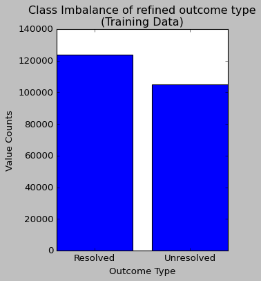

```python
# Assess class imbalance
ensemble_imbalance = y_train.value_counts()
ensemble_imbalance = pd.DataFrame(ensemble_imbalance)

plt.figure(figsize=(4,5))
plt.style.use('classic')
plt.bar(ensemble_imbalance.index,ensemble_imbalance["count"])
plt.title("Class Imbalance of refined outcome type\n(Training Data)")
plt.xlabel("Outcome Type")
plt.ylabel("Value Counts")
```

### 4.2 - Building the Model

```python
# Building the model
from sklearn.ensemble import RandomForestClassifier

categorical_features = [
    "Urban_rural_flag",
    "Quarter",
    "Spatial_quarter",
    "Crime type"
]

numeric_features = ["LSOA_freq"]

preprocess = ColumnTransformer(
    transformers=[
        ("cat", OneHotEncoder(handle_unknown="ignore"), categorical_features),
        ("num", "passthrough", numeric_features)
    ]
)

rf = RandomForestClassifier(
    n_estimators=500,
    min_samples_leaf=10,
    random_state=13,
    n_jobs=-1,
    class_weight="balanced"
)

rf_model = Pipeline(steps=[
    ("preprocess", preprocess),
    ("rf", rf)
])

from sklearn.model_selection import cross_val_score

cv_scores = cross_val_score(
    rf_model,
    X_train,
    y_train,
    cv=5,
    scoring="f1_macro"
)

print("CV F1 scores:", cv_scores)
print("Mean CV F1:", cv_scores.mean())

rf_model.fit(X_train, y_train)
```

```
CV F1 scores: [0.70978734 0.71065271 0.70700498 0.71102429 0.70591523]
Mean CV F1: 0.7088769089405478
```

```
Pipeline(steps=[('preprocess',
                 ColumnTransformer(transformers=[('cat',
                                                  OneHotEncoder(handle_unknown='ignore'),
                                                  ['Urban_rural_flag',
                                                   'Quarter', 'Spatial_quarter',
                                                   'Crime type']),
                                                 ('num', 'passthrough',
                                                  ['LSOA_freq'])])),
                ('rf',
                 RandomForestClassifier(class_weight='balanced',
                                        min_samples_leaf=10, n_estimators=500,
                                        n_jobs=-1, random_state=13))])
```

#### 4.2.1 - Model Evaluation

```python
# Evaluation - Classification Report
from sklearn.metrics import classification_report, confusion_matrix, f1_score, ConfusionMatrixDisplay

y_pred = rf_model.predict(X_test)

print(classification_report(y_test, y_pred))
print("F1 (macro):", f1_score(y_test, y_pred, average="macro"))
```

```
              precision    recall  f1-score   support

    Resolved       0.76      0.68      0.72     30926
  Unresolved       0.66      0.74      0.70     26253

    accuracy                           0.71     57179
   macro avg       0.71      0.71      0.71     57179
weighted avg       0.71      0.71      0.71     57179

F1 (macro): 0.7083810428957187
```

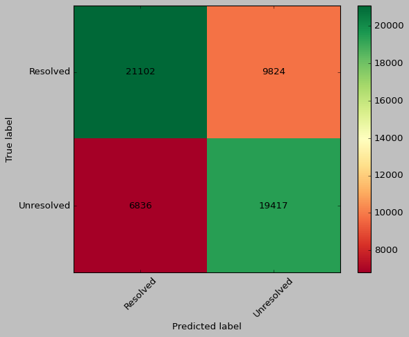

```python
# Evaluation - Confusion Matrix
ConfusionMatrixDisplay.from_estimator(
    rf_model, X_test, y_test, cmap="RdYlGn", text_kw={"color": "black"}
)
plt.style.use('classic')
plt.xticks(rotation=45)
plt.show()
```

### 4.3 - Urban vs Rural Comparison

#### 4.3.1 - Predictive Performance

```python
# Urban vs Rural Predictive Performance
rural_only = X_test["Urban_rural_flag"] == "Rural"
urban_only = X_test["Urban_rural_flag"] == "Urban"

print("RURAL RESULTS")
print(classification_report(
    y_test[rural_only],
    y_pred[rural_only]
))

print("URBAN RESULTS")
print(classification_report(
    y_test[urban_only],
    y_pred[urban_only]
))
```

```
RURAL RESULTS
              precision    recall  f1-score   support

    Resolved       0.76      0.71      0.73      4582
  Unresolved       0.68      0.73      0.70      3859

    accuracy                           0.72      8441
   macro avg       0.72      0.72      0.72      8441
weighted avg       0.72      0.72      0.72      8441

URBAN RESULTS
              precision    recall  f1-score   support

    Resolved       0.75      0.68      0.71     26344
  Unresolved       0.66      0.74      0.70     22394

    accuracy                           0.71     48738
   macro avg       0.71      0.71      0.71     48738
weighted avg       0.71      0.71      0.71     48738
```

#### 4.3.2 - Feature Importance

```python
# Urban vs Rural Feature Importance
from sklearn.inspection import permutation_importance

preprocessor = rf_model.named_steps["preprocess"]
rf_model2 = rf_model.named_steps["rf"]

X_rural = preprocessor.transform(X_test[rural_only]).toarray()
X_urban = preprocessor.transform(X_test[urban_only]).toarray()
y_rural = y_test[rural_only]
y_urban = y_test[urban_only]

# Permutation importance
rural_model = permutation_importance(
    rf_model2,
    X_rural,
    y_rural,
    n_repeats=3,
    random_state=13,
    scoring="f1_macro",
    n_jobs=-1
)

urban_model = permutation_importance(
    rf_model2,
    X_urban,
    y_urban,
    n_repeats=3,
    random_state=13,
    scoring="f1_macro",
    n_jobs=-1
)

# Recover encoded feature names
feature_names = preprocessor.get_feature_names_out()

rural_importance = pd.DataFrame({
    "Feature": feature_names,
    "Importance": rural_model.importances_mean
}).sort_values("Importance", ascending=False)

urban_importance = pd.DataFrame({
    "Feature": feature_names,
    "Importance": urban_model.importances_mean
}).sort_values("Importance", ascending=False)
```

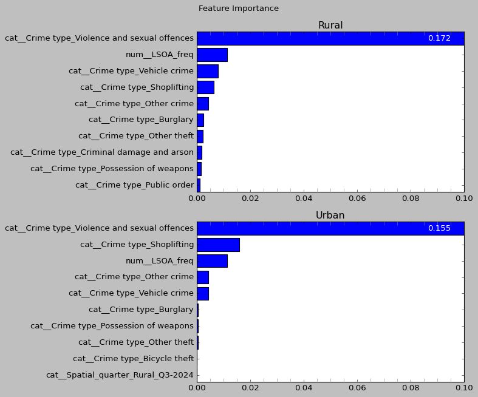

```python
# Feature Importance plot
from matplotlib.ticker import MultipleLocator

fig, axes = plt.subplots(2, 1, figsize=(10,8))
plt.style.use('classic')

axes[0].barh(
    rural_importance.head(10)["Feature"],
    rural_importance.head(10)["Importance"]
)
axes[0].invert_yaxis()
axes[0].set_title("Rural")
axes[0].set_xlim(0, 0.1)
axes[0].xaxis.set_minor_locator(MultipleLocator(0.005))
axes[0].tick_params(which='minor', length=5, color='gray')

for i, (feat, val) in enumerate(zip(
    rural_importance.head(10)["Feature"],
    rural_importance.head(10)["Importance"]
)):
    if feat == "cat__Crime type_Violence and sexual offences":
        axes[0].text(
            0.095, i, f"{val:.3f}",
            va="center", ha="right", color='white'
        )


axes[1].barh(
    urban_importance.head(10)["Feature"],
    urban_importance.head(10)["Importance"]
)
axes[1].invert_yaxis()
axes[1].set_title("Urban")
axes[1].set_xlim(0, 0.1)
axes[1].xaxis.set_minor_locator(MultipleLocator(0.005))
axes[1].tick_params(which='minor', length=5, color='gray')

for i, (feat, val) in enumerate(zip(
    urban_importance.head(10)["Feature"],
    urban_importance.head(10)["Importance"]
)):
    if feat == "cat__Crime type_Violence and sexual offences":
        axes[1].text(
            0.095, i, f"{val:.3f}",
            va="center", ha="right", color='white'
        )

plt.tight_layout()
plt.suptitle("Feature Importance", y=1.02)
plt.show()
```

### 4.4 - Conclusion

The Random Forest model demonstrates stable predictive performance when classifying binary crime outcomes. F1-scores are highly consistent under 5-fold cross-validation, ranging from 0.706 to 0.711, with a mean F1-score of 0.709. This indicated good generalisability and little evidence of overfitting. The similarity between the cross-validation performance and the independent test-set macro F1-score (0.708) further suggests that the model performs consistently on unseen data.

On the test set, the model achieved an overall accuracy of 71%. Precision and recall were reasonably balanced across both classes, with the model slightly better at identifying unresolved outcomes (recall = 0.74) than resolved outcomes (recall = 0.68). The confusion matrix showed that both classes were predicted successfully without substantial bias towards either outcome, indicating that crime type, temporal, and spatial features contain meaningful information for predicting recorded crime outcomes.

Model performance was evaluated separately on rural and urban subsets to assess whether predictive relationships differ by geography. Results show near-identical performance across both contexts, with rural data achieving a macro F1-score of 0.72 and urban data achieving 0.71. Precision and recall values were also highly consistent across both subsets, indicating that the relationship between crime characteristics and outcome resolution is stable across spatial settings.

These findings suggest that although crime distributions differ between rural and urban areas, the underlying structure governing outcome resolution is broadly consistent. This implies that observed differences in policing outcomes are more likely driven by differences in crime composition rather than fundamentally different outcome-generating processes across geography.

Crime outcome prediction is primarily driven by crime type rather than geographic classification. While rural and urban areas exhibit broadly similar predictive structures, subtle differences exist in the relative importance of specific offence types, with shoplifting being more predictive in urban areas and vehicle crime and burglary showing relatively greater importance in rural contexts. These findings partially align with reported community policing priorities, although the overall effect of geography is limited compared to crime composition. Feature importance values are small and highly skewed due to dominance of a single feature.